# Project 2

```python
import pandas as pd
import numpy as np

import matplotlib.pyplot as plt
import seaborn as sns

%matplotlib inline

plt.style.use("ggplot")
sns.set_theme(style="whitegrid")

import warnings
warnings.filterwarnings("ignore")
```

```python
df = pd.read_excel("C:/Users/User/Desktop/Data Analyst Projects/Decode Lab internship/Cleaned dataset.xlsx")
```

```python
df.head()
```

|  | OrderID | Date | CustomerID | Product | Quantity | UnitPrice | ShippingAddress | PaymentMethod | OrderStatus | TrackingNumber | ItemsInCart | CouponCode | ReferralSource | TotalPrice |
| --- | --- | --- | --- | --- | --- | --- | --- | --- | --- | --- | --- | --- | --- | --- |
| 0 | ORD200000 | 2023-01-04 | C72649 | Monitor | 5 | 570.62 | 928 Main St | Debit Card | Shipped | TRK37947903 | 7 | SAVE10 | Instagram | 2853.10 |
| 1 | ORD200001 | 2024-08-23 | C75739 | Phone | 2 | 151.35 | 823 Main St | Online | Shipped | TRK91186779 | 3 | SAVE10 | Referral | 302.70 |
| 2 | ORD200002 | 2024-02-27 | C81728 | Tablet | 5 | 550.68 | 512 Main St | Credit Card | Cancelled | TRK42903982 | 8 | FREESHIP | Email | 2753.40 |
| 3 | ORD200003 | 2023-10-15 | C33540 | Chair | 1 | 273.19 | 275 Main St | Debit Card | Returned | TRK62788070 | 5 | SAVE10 | Facebook | 273.19 |
| 4 | ORD200004 | 2025-05-08 | C81840 | Printer | 4 | 626.01 | 668 Main St | Online | Delivered | TRK29241424 | 8 | SAVE10 | Email | 2504.04 |

```python
df.shape
```

```
(1200, 14)
```

```python
df.info()
```

```
<class 'pandas.core.frame.DataFrame'>
RangeIndex: 1200 entries, 0 to 1199
Data columns (total 14 columns):
 #   Column           Non-Null Count  Dtype
---  ------           --------------  -----
 0   OrderID          1200 non-null   object
 1   Date             1200 non-null   datetime64[ns]
 2   CustomerID       1200 non-null   object
 3   Product          1200 non-null   object
 4   Quantity         1200 non-null   int64
 5   UnitPrice        1200 non-null   float64
 6   ShippingAddress  1200 non-null   object
 7   PaymentMethod    1200 non-null   object
 8   OrderStatus      1200 non-null   object
 9   TrackingNumber   1200 non-null   object
 10  ItemsInCart      1200 non-null   int64
 11  CouponCode       1200 non-null   object
 12  ReferralSource   1200 non-null   object
 13  TotalPrice       1200 non-null   float64
dtypes: datetime64[ns](1), float64(2), int64(2), object(9)
memory usage: 131.4+ KB
```

```python
df.describe
```

[output not shown]

[output cut: 25 more lines]

```python
df.isnull().sum()
```

```
OrderID            0
Date               0
CustomerID         0
Product            0
Quantity           0
UnitPrice          0
ShippingAddress    0
PaymentMethod      0
OrderStatus        0
TrackingNumber     0
ItemsInCart        0
CouponCode         0
ReferralSource     0
TotalPrice         0
dtype: int64
```

```python
df.duplicated().sum()
```

```
np.int64(0)
```

```python
df.describe(include='all')
```

|  | OrderID | Date | CustomerID | Product | Quantity | UnitPrice | ShippingAddress | PaymentMethod | OrderStatus | TrackingNumber | ItemsInCart | CouponCode | ReferralSource | TotalPrice |
| --- | --- | --- | --- | --- | --- | --- | --- | --- | --- | --- | --- | --- | --- | --- |
| count | 1200 | 1200 | 1200 | 1200 | 1200.000000 | 1200.000000 | 1200 | 1200 | 1200 | 1200 | 1200.000000 | 1200 | 1200 | 1200.000000 |
| unique | 1200 | NaN | 1189 | 7 | NaN | NaN | 655 | 5 | 5 | 1200 | NaN | 4 | 5 | NaN |
| top | ORD200000 | NaN | C38840 | Printer | NaN | NaN | 533 Main St | Online | Cancelled | TRK37947903 | NaN | FREESHIP | Instagram | NaN |
| freq | 1 | NaN | 2 | 181 | NaN | NaN | 8 | 258 | 250 | 1 | NaN | 313 | 259 | NaN |
| mean | NaN | 2024-03-22 16:58:48 | NaN | NaN | 2.945833 | 356.412750 | NaN | NaN | NaN | NaN | 5.485000 | NaN | NaN | 1053.968300 |
| min | NaN | 2023-01-01 00:00:00 | NaN | NaN | 1.000000 | 11.390000 | NaN | NaN | NaN | NaN | 1.000000 | NaN | NaN | 11.390000 |
| 25% | NaN | 2023-08-03 18:00:00 | NaN | NaN | 2.000000 | 186.062500 | NaN | NaN | NaN | NaN | 4.000000 | NaN | NaN | 410.520000 |
| 50% | NaN | 2024-03-23 00:00:00 | NaN | NaN | 3.000000 | 364.210000 | NaN | NaN | NaN | NaN | 5.000000 | NaN | NaN | 823.615000 |
| 75% | NaN | 2024-11-08 12:00:00 | NaN | NaN | 4.000000 | 521.570000 | NaN | NaN | NaN | NaN | 7.000000 | NaN | NaN | 1578.475000 |
| max | NaN | 2025-06-30 00:00:00 | NaN | NaN | 5.000000 | 699.930000 | NaN | NaN | NaN | NaN | 10.000000 | NaN | NaN | 3456.400000 |
| std | NaN | NaN | NaN | NaN | 1.407557 | 197.177146 | NaN | NaN | NaN | NaN | 2.281983 | NaN | NaN | 819.856558 |

```python
df.nunique()
```

```
OrderID            1200
Date                671
CustomerID         1189
Product               7
Quantity              5
UnitPrice          1193
ShippingAddress     655
PaymentMethod         5
OrderStatus           5
TrackingNumber     1200
ItemsInCart          10
CouponCode            4
ReferralSource        5
TotalPrice         1195
dtype: int64
```

```python
print("Mean:", df["Quantity"].mean())
print("Median:", df["Quantity"].median())
print("Mode:", df["Quantity"].mode()[0])
print("Minimum:", df["Quantity"].min())
print("Maximum:", df["Quantity"].max())
print("Standard Deviation:", df["Quantity"].std())
```

```
Mean: 2.9458333333333333
Median: 3.0
Mode: 1
Minimum: 1
Maximum: 5
Standard Deviation: 1.4075570987983197
```

```python
print("Mean:", df["UnitPrice"].mean())
print("Median:", df["UnitPrice"].median())
print("Mode:", df["UnitPrice"].mode()[0])
print("Minimum:", df["UnitPrice"].min())
print("Maximum:", df["UnitPrice"].max())
print("Standard Deviation:", df["UnitPrice"].std())
```

```
Mean: 356.41275
Median: 364.21
Mode: 127.18
Minimum: 11.39
Maximum: 699.93
Standard Deviation: 197.1771464149122
```

```python
print("Mean:", df["TotalPrice"].mean())
print("Median:", df["TotalPrice"].median())
print("Mode:", df["TotalPrice"].mode()[0])
print("Minimum:", df["TotalPrice"].min())
print("Maximum:", df["TotalPrice"].max())
print("Standard Deviation:", df["TotalPrice"].std())
```

```
Mean: 1053.9683
Median: 823.615
Mode: 211.14
Minimum: 11.39
Maximum: 3456.4
Standard Deviation: 819.8565583646451
```

```python
df["Date"] = pd.to_datetime(df["Date"])
```

```python
df["Date"].head()
```

```
0   2023-01-04
1   2024-08-23
2   2024-02-27
3   2023-10-15
4   2025-05-08
Name: Date, dtype: datetime64[ns]
```

```python
df["Year"] = df["Date"].dt.year
df["Month"] = df["Date"].dt.month_name()
df["Day"] = df["Date"].dt.day
```

```python
df["Product"].value_counts()
```

```
Product
Printer    181
Tablet     179
Chair      178
Laptop     173
Desk       170
Monitor    163
Phone      156
Name: count, dtype: int64
```

```python
df["PaymentMethod"].value_counts()
```

```
PaymentMethod
Online         258
Cash           246
Credit Card    234
Debit Card     232
Gift Card      230
Name: count, dtype: int64
```

```python
df["OrderStatus"].value_counts()
```

```
OrderStatus
Cancelled    250
Returned     247
Pending      237
Shipped      235
Delivered    231
Name: count, dtype: int64
```

```python
df["ReferralSource"].value_counts()
```

```
ReferralSource
Instagram    259
Email        250
Google       241
Facebook     228
Referral     222
Name: count, dtype: int64
```

```python
df["CouponCode"].value_counts()
```

```
CouponCode
FREESHIP     313
No Coupon    309
WINTER15     292
SAVE10       286
Name: count, dtype: int64
```

## Distribution of Quantity

This analysis shows how many products customers purchase in each order.

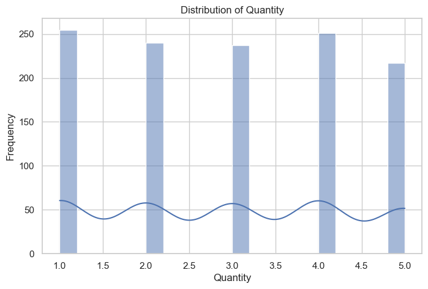

```python
plt.figure(figsize=(8,5))

sns.histplot(df["Quantity"], bins=20, kde=True)

plt.title("Distribution of Quantity")
plt.xlabel("Quantity")
plt.ylabel("Frequency")

plt.show()
```

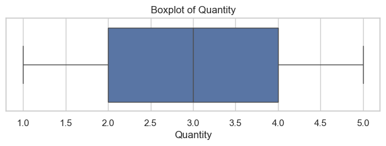

```python
plt.figure(figsize=(8,2))

sns.boxplot(x=df["Quantity"])

plt.title("Boxplot of Quantity")

plt.show()
```

## Distribution of Unit Price

This analysis helps understand the pricing pattern of products.

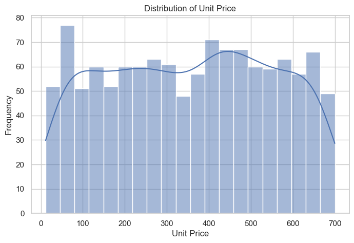

```python
plt.figure(figsize=(8,5))

sns.histplot(df["UnitPrice"], bins=20, kde=True)

plt.title("Distribution of Unit Price")

plt.xlabel("Unit Price")

plt.ylabel("Frequency")

plt.show()
```

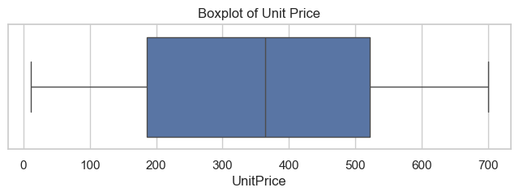

```python
plt.figure(figsize=(8,2))

sns.boxplot(x=df["UnitPrice"])

plt.title("Boxplot of Unit Price")

plt.show()
```

## Distribution of Total Price

Total Price represents the total order value and helps understand customer spending.

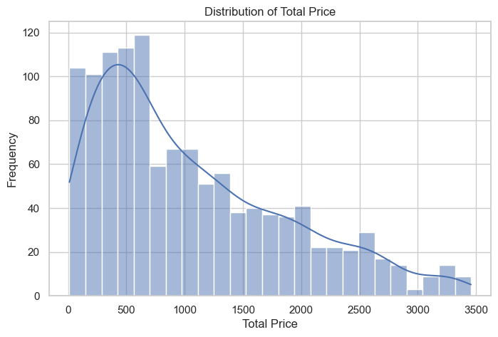

```python
plt.figure(figsize=(8,5))

sns.histplot(df["TotalPrice"], bins=25, kde=True)

plt.title("Distribution of Total Price")

plt.xlabel("Total Price")

plt.ylabel("Frequency")

plt.show()
```

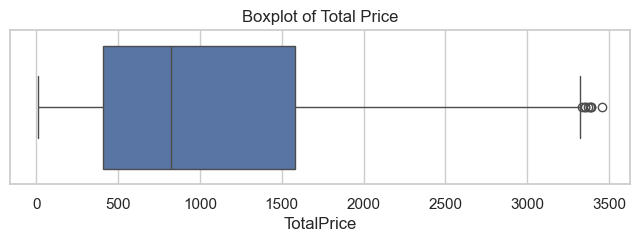

```python
plt.figure(figsize=(8,2))

sns.boxplot(x=df["TotalPrice"])

plt.title("Boxplot of Total Price")

plt.show()
```

### Insight

- Most customer orders have relatively lower transaction values, whereas only a few orders contribute exceptionally high revenue.
- The distribution shows positive skewness, meaning high-value purchases occur less frequently.
- Large order values are primarily driven by higher-priced products or larger purchase quantities.

## Which products are ordered the most?

```python
top_products = df["Product"].value_counts()

top_products
```

```
Product
Printer    181
Tablet     179
Chair      178
Laptop     173
Desk       170
Monitor    163
Phone      156
Name: count, dtype: int64
```

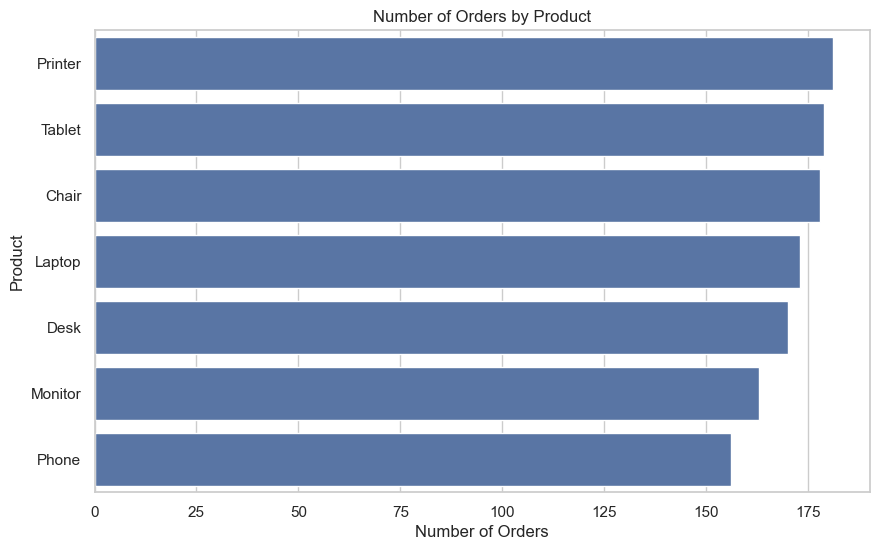

```python
plt.figure(figsize=(10,6))

sns.countplot(
    y="Product",
    data=df,
    order=df["Product"].value_counts().index
)

plt.title("Number of Orders by Product")

plt.xlabel("Number of Orders")

plt.ylabel("Product")

plt.show()
```

### Insight

- Product demand is fairly balanced across all product categories.
- Printer recorded the highest number of customer orders, followed closely by Tablet and Chair.
- Phone received comparatively fewer orders, indicating relatively lower purchase frequency.

### This section identifies the revenue with products

```python
product_revenue = df.groupby("Product")["TotalPrice"].sum().sort_values(ascending=False)

product_revenue
```

```
Product
Chair      195620.11
Printer    195612.61
Laptop     192126.56
Tablet     186568.95
Monitor    175651.41
Desk       167459.93
Phone      151722.39
Name: TotalPrice, dtype: float64
```

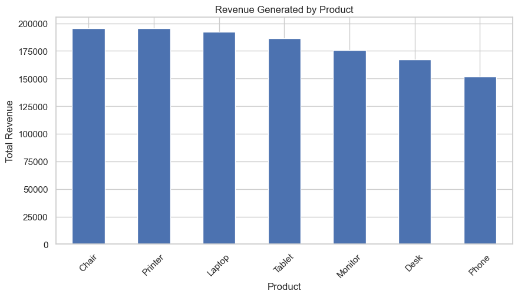

```python
plt.figure(figsize=(10,5))

product_revenue.plot(kind="bar")

plt.title("Revenue Generated by Product")
plt.xlabel("Product")
plt.ylabel("Total Revenue")

plt.xticks(rotation=45)

plt.show()
```

### Insight

- Revenue generation differs from order frequency, indicating that product price also plays an important role.
- Chair generated the highest overall revenue despite having fewer orders than Printer.
- High-value products contribute significantly to total revenue even if their sales volume is comparatively lower.

## Payment Method Analysis

This section shows the preferred payment methods used by customers.

```python
payment = df["PaymentMethod"].value_counts()

payment
```

```
PaymentMethod
Online         258
Cash           246
Credit Card    234
Debit Card     232
Gift Card      230
Name: count, dtype: int64
```

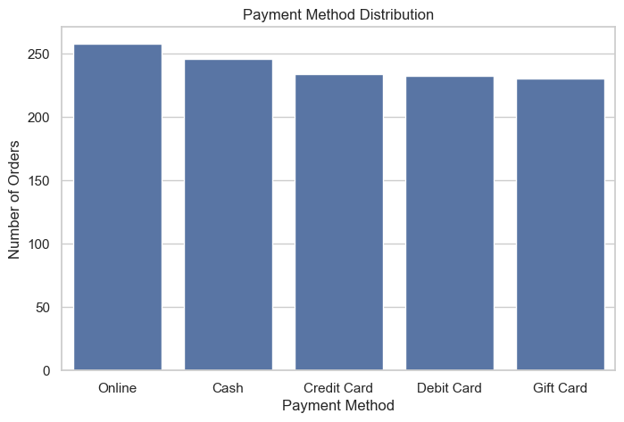

```python
plt.figure(figsize=(8,5))

sns.countplot(
    data=df,
    x="PaymentMethod",
    order=df["PaymentMethod"].value_counts().index
)

plt.title("Payment Method Distribution")
plt.xlabel("Payment Method")
plt.ylabel("Number of Orders")

plt.show()
```

### Insight

- Customers use multiple payment methods, showing flexibility in payment preferences.
- Online payments are the most frequently used payment option, reflecting customers' preference for digital transactions.
- Other payment methods also maintain a fairly balanced share, suggesting no heavy dependence on a single payment channel.

## Order Status Analysis

This section examines the distribution of different order statuses.

```python
status = df["OrderStatus"].value_counts()

status
```

```
OrderStatus
Cancelled    250
Returned     247
Pending      237
Shipped      235
Delivered    231
Name: count, dtype: int64
```

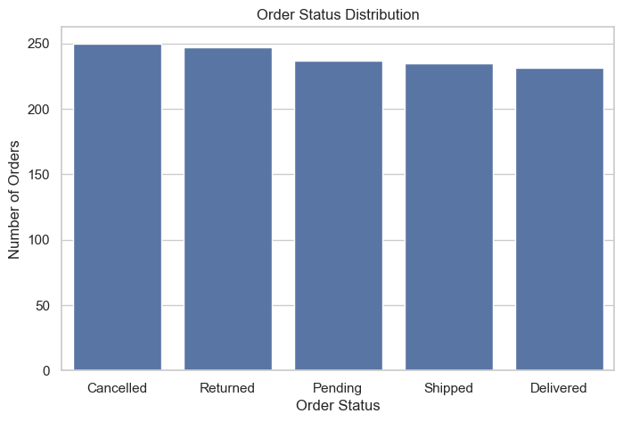

```python
plt.figure(figsize=(8,5))

sns.countplot(
    data=df,
    x="OrderStatus",
    order=df["OrderStatus"].value_counts().index
)

plt.title("Order Status Distribution")
plt.xlabel("Order Status")
plt.ylabel("Number of Orders")

plt.show()
```

### Insight

- Orders are distributed across Delivered, Pending, Shipped, Cancelled, and Returned statuses.
- The relatively balanced distribution indicates that orders are processed through different stages of the fulfillment cycle.
- Cancelled and Returned orders represent opportunities for improving customer satisfaction and operational efficiency.

## Monthly Sales Trend

```python
month_order = [
    "January","February","March","April","May","June",
    "July","August","September","October","November","December"
]

df["Month"] = pd.Categorical(
    df["Month"],
    categories=month_order,
    ordered=True
)
```

```python
monthly_sales = df.groupby("Month")["TotalPrice"].sum()

monthly_sales
```

```
Month
January      124313.23
February     112344.78
March        123840.93
April        109186.05
May          135142.59
June         170616.13
July          85784.64
August        86343.21
September     69321.65
October       89834.82
November      75493.43
December      82540.50
Name: TotalPrice, dtype: float64
```

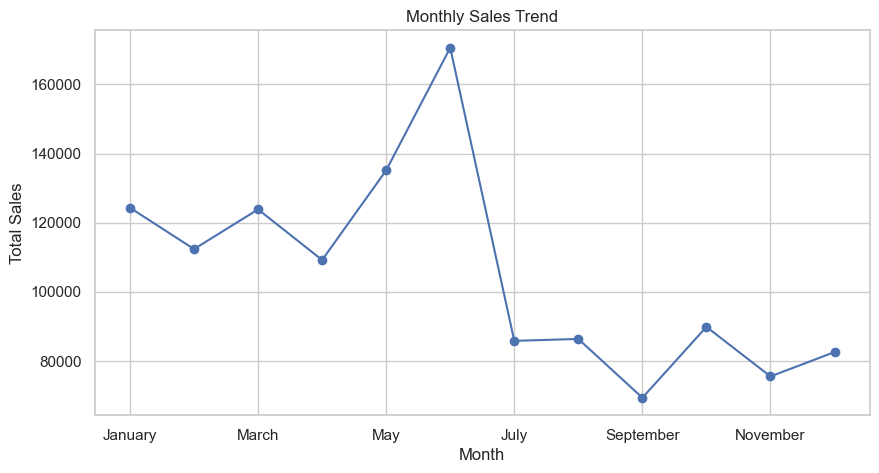

```python
plt.figure(figsize=(10,5))

monthly_sales.plot(marker="o")

plt.title("Monthly Sales Trend")
plt.xlabel("Month")
plt.ylabel("Total Sales")

plt.grid(True)

plt.show()
```

### Insight

- Sales fluctuate across different months instead of remaining constant.
- Certain months contribute noticeably higher revenue, indicating seasonal variations in customer purchasing behavior.
- Understanding these monthly trends can help businesses improve inventory planning and promotional campaigns during peak periods.